# Week 6 Exercises: GitHub, OSC, and software

Author

Affiliations

Jelmer Poelstra

[CFAES Bioinformatics Core, Ohio State University](https://go.osu.edu/bioinformatics-core)

[Dept. of Plant Pathology, Ohio State University](https://plantpath.osu.edu)

Week starts on

September 28, 2026

Page last modified

September 30, 2026

## Introduction

### Overview

In Exercise 1, you’ll practice with the GitHub material from last week that wasn’t part of Graded Assignment 2. In Exercises 2 and 3, you’ll practice with this week’s material: you’ll explore OSC’s login and compute nodes, and find and run software with modules and containers.

**TipLecture page exercises**

Make sure to do any of the exercises on this week’s lecture pages that we did not do in class. Also, if you struggled with any of the exercises we did do in class, go over those again.

### Setting up

Start a VS Code session through OSC OnDemand in the folder `/fs/ess/PAS3493/people/$USER`.

## Exercise 1: GitHub

1. Go to the GitHub website, log in, and **create a new GitHub repository**. This will be the remote counterpart of the Git repo you made as part of last week’s assignment.
   - You can give the GitHub repo any name you want.
   - Like we did in class, keep the repo *Public* (the default), because that’s needed for the instructor tagging exercise later on[^1].
   - Also like we did in class, don’t let GitHub add a README or any other files when you create the repo.
2. **Navigate** to your dir for last week’s assignment in the VS Code terminal (you can also use the “Open Folder” option in VS Code to open that folder if you want).
3. Set up a **connection** between the Git repo and the GitHub counterpart using Git commands.
4. **Push** your local repo to the online counterpart.
5. Explore your repo on **GitHub**. Does your `README.md` render well? Can you see all your commits? Are your `data` and `results` dirs there? Why or why not?
6. You will hand in the remaining assignments for this course by “tagging” the instructors in a GitHub Issue. To make sure you know how this works, let’s do a test run. On GitHub, open a **GitHub Issue** for your repo: click the Issues tab and then “*New Issue*”.
   - Under “*Add a title*”, give the issue a title like “Testing whether tagging works”.
   - Under “*Add a description*”, tag both instructors using `@<username>` syntax:

     ```
     [GitHub Issue body]
     ```

     ```
     Hey @jelmerp and @kstarr791, can you please take a look at my repo?
     ```

   - Click the green “**Create**” button to post your Issue. If the tagging worked, the `@jelmerp` and `@kstarr791` should have turned into links to the instructors’ GitHub profiles.

   **Click here to see screenshots of the tagging.**
   - When you type the tags, it will look like regular plain text:

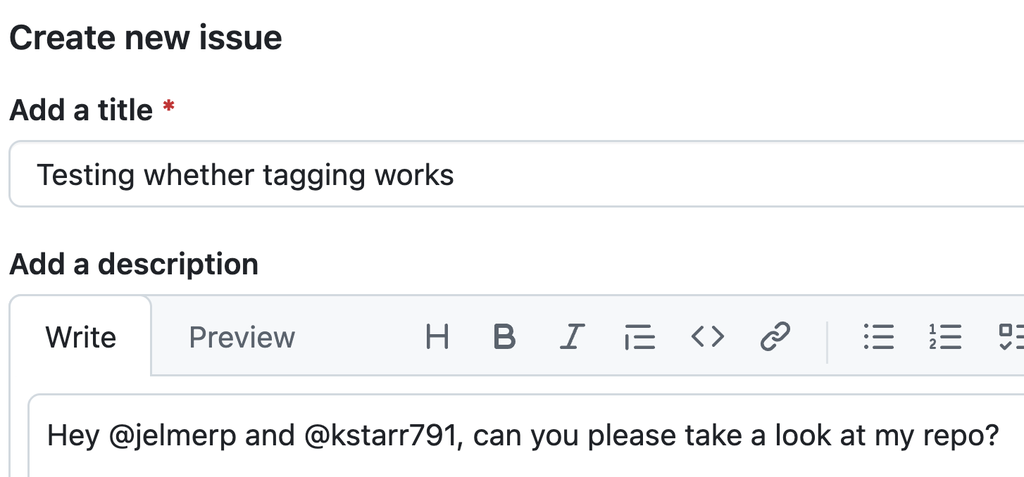

   - But once you create the issue, the tags, if they are valid, will turn bold and underlined, and are links to the instructors’ GitHub profiles. (You shouldn’t see a yellow background, though: that is only because I tagged myself to get this screenshot.)

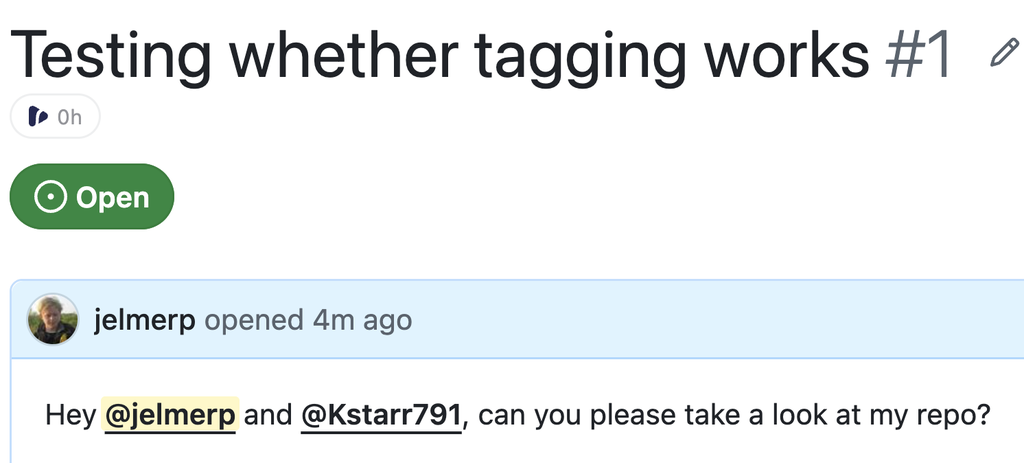

7. Back in VS Code, add a line to your `README.md` to describe that you created a GitHub repo on today’s date (include the repo’s URL in the note).
8. **Commit** the change to `README.md` to your Git repo.
9. **Push** to the remote and on GitHub, check that the changes were applied in the online repo.

## Exercise 2: Login versus compute nodes

In GA1, you found out that your VS Code session runs on a compute node. Let’s explore that a bit more, and compare with a login node.

1. In OnDemand, open a shell on a login node by clicking “Clusters” in the top bar and then “**Cardinal Shell Access**”. You should see many lines of text printed to the terminal, which is standard information that OSC prints on login (but not compute) nodes, including details about your Project’s usage of its *storage quota*[^2].
2. In the Cardinal shell, run the command `hostname`, which prints the name of the node that you’re on (like `echo $HOSTNAME` that you used in GA1). Then, run the same command in your VS Code terminal, and compare the outputs. What in each node name tells you whether it is a login node or a compute node? And which cluster is each node part of?
3. Why does the Cardinal shell put you on a login node, whereas your VS Code session is on a compute node? And what does this mean for what you should (not) do in the Cardinal shell? For example, would it be OK to run FastQC on all FASTQ files of the Garrigós data there?
4. In the Cardinal shell, navigate to `/fs/ess/PAS3493/people/$USER` and list its contents. Do you see the **same files** as in VS Code, even though your VS Code session is running on a different cluster?
5. In your VS Code terminal, load the FastQC module and check that `fastqc -v` works. Predict whether `fastqc -v` will also work in the following two scenarios, and then check your predictions and interpret the results:
   - In the Cardinal shell.
   - In a second VS Code terminal (click the `+` icon in the terminal panel or the downward arrow next to it — see the screenshots below).

   **Click here for screenshots on the second VS Code terminal.**

   If you click the downward arrow next to the `+` icon in the terminal panel, you get several options:

[figure not shown]

   I like the “**Split Terminal**” option best, which allows you to see both terminals at once:

[figure not shown]

   If you just click the `+` icon, or select “**New Terminal**” from the dropdown menu, you get a new terminal that takes up the entire panel, and you can switch between terminals using the panel on the side:

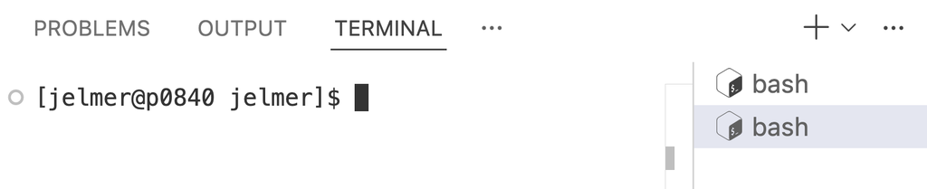

   Either way, having multiple terminals can be quite handy!
6. In the lecture’s self-study exercise on modules, `module spider salmon` in VS Code said there was no Salmon module. Run the same command in the Cardinal shell. What do you get, and why?

## Exercise 3: A specific software version

Say that you want to compare your results with those of a published study that used FastQC version **0.11.9**, so you want to use that exact version as well.

1. Is FastQC version 0.11.9 available as an OSC module?
2. Get the URI of a Seqera container that contains FastQC version 0.11.9.
3. Check the container’s FastQC version.
4. Load the `fastqc/0.12.1` module. You now have access to two different versions of FastQC. Before running anything, **predict** which version `fastqc -v` will print when you run it with and without the container prefix. Then, run both commands to check.

## Solutions

### Exercise 1

**2.** Navigate to your dir for last week’s assignment**

```bash
cd GA2
```

**3.** Set up a connection to the online repo**

```bash
# (replace <SSH-URL-to-repo> with your actual SSH (not HTTPS!) URL,
#  which looks like 'git@github.com:<github-username>/<repo-name>.git')
git remote add origin <SSH-URL-to-repo>
```

**4.** Push your local repo to the online one you just created**

When you push to a remote repo for the first time, you need to add the `-u origin main` part:

```bash
git push -u origin main
```

**5.** Are `data` and `results` on GitHub?**

No: you listed these dirs in your `.gitignore` file, so their files were never committed, and `git push` only uploads commits. (Your `.gitignore` file itself *is* on GitHub, since you did commit it.)

**8.** Commit the change you made to `README.md`**

```bash
# Stage the change to README.md
git add README.md

# Make a commit with a message describing the change
git commit -m "Update README with GitHub repo information"
```

**9.** Push to the remote again**

Since you’ve pushed to this remote before, a simple `git push` works:

```bash
git push
```

### Exercise 2

**2.** Node names**

In the Cardinal shell:

```bash
hostname
```

```
cardinal-login01.hpc.osc.edu
```

In VS Code:

```bash
hostname
```

```
p0231.ten.osc.edu
```

*(Your exact node names will differ.)*

- The Cardinal shell is on a **login node**, as you can tell from the `login` in its name, and it is on the **Cardinal** cluster, as the name also says.
- VS Code is on a **compute node**, whose name is a letter followed by digits: the `p` means it is part of the **Pitzer** cluster.

**3.** Why a login node versus a compute node**

- The “Clusters” shell connects you directly to the cluster, without requesting any resources, so you end up on a login node.
- By contrast, when you start a Code Server session, you request a compute job, and the job scheduler assigns your session to a compute node. This is because Code Server itself needs resources to run, and if many users were to run Code Server on a login node, it could become overloaded.
- In the Cardinal shell, you share a login node with many other users, so you should only run light tasks there, like navigating, listing files, or checking which modules are available. Running FastQC on dozens of FASTQ files is a real analysis that would take a while and use considerable resources: do that on a compute node instead.

**4.** Files across clusters**

```bash
cd /fs/ess/PAS3493/people/$USER
ls
```

You see the same files, because all of OSC’s nodes and clusters share the same file systems.

**5.** Loaded modules in other shells**

```bash
# In the first VS Code terminal:
module load fastqc/0.12.1
fastqc -v
```

```
FastQC v0.12.1
```

```bash
# In the Cardinal shell, and in a second VS Code terminal:
fastqc -v
```

```
bash: fastqc: command not found...
Failed to search for file: GDBus.Error:org.freedesktop.DBus.Error.NameHasNoOwner: Could not activate remote peer.
```

It doesn’t work in either of them: loading a module only affects the **shell session** you loaded it in. The second VS Code terminal is on the same compute node as the first one, but it’s a separate shell session, so you would need to load the module there as well.

**6.** Salmon on Cardinal**

In the Cardinal shell, `module spider salmon` finds a Salmon module, whereas in VS Code (on Pitzer) it didn’t. The clusters have mostly, but not entirely, the same modules.

Therefore, if you want to use modules, you should check that the software you need is available on the cluster you’ll run your analysis on. If that seems like a pain, I agree, and it’s one reason I prefer containers. Also note that this is quite an old version of Salmon (1.4.0, from 2020), whereas a container gives you the latest version.

```bash
module spider salmon
```

```
-------------------------------------------------------------------------------------------
  salmon: salmon/1.4.0
-------------------------------------------------------------------------------------------

    This module can be loaded directly: module load salmon/1.4.0

    Help:
      This module loads salmon
      Configured and installed with modules:
      No modules loaded
```

### Exercise 3

**1.** Is FastQC 0.11.9 available as a module?**

No, only version 0.12.1 is available:

```bash
module spider fastqc
```

```
--------------------------------------------------------------------------------
  fastqc: fastqc/0.12.1
--------------------------------------------------------------------------------

    This module can be loaded directly: module load fastqc/0.12.1
```

**2.** Get a container with FastQC 0.11.9**

At https://seqera.io/containers, search for `fastqc`, select version `0.11.9` in the dropdown menu next to the `bioconda::fastqc` hit, and then proceed as shown in the lecture (don’t forget to select `Singularity`).

Your URI will look like `oras://community.wave.seqera.io/library/fastqc:0.11.9--<hash>`.

**3.** Check the container’s FastQC version**

```bash
apptainer exec oras://community.wave.seqera.io/library/fastqc:0.11.9--1cc469c72218f8fc \
    fastqc -v
```

```
INFO:    Downloading oras image
352.3MiB / 352.3MiB [====================================================================================================================================================================================================] 100 % 43.1 MiB/s 0s
INFO:    gocryptfs not found, will not be able to use gocryptfs
FastQC v0.11.9
```

**4.** Compare the module and container versions**

```bash
module load fastqc/0.12.1

apptainer exec oras://community.wave.seqera.io/library/fastqc:0.11.9--1cc469c72218f8fc \
    fastqc -v
```

```
INFO:    gocryptfs not found, will not be able to use gocryptfs
FastQC v0.11.9
```

```bash
fastqc -v
```

```
FastQC v0.12.1
```

With the container, you always get version 0.11.9, regardless of which modules are loaded: the container uses the software installed inside it. Without the container, you get the version from the loaded module.

Back to top

## Footnotes

[^1]: You can also make it private later if you want. Or you can make it private from the start, but then you need to add the instructors as *collaborators* in the repo’s settings.
[^2]: But the corresponding information on the OnDemand dashboard is much more user-friendly, so I wouldn’t worry too much about the quota info printed in the shell.